# Question 3

Sai Muktevi

2/19/2021

# Is the average amount of money raised different depending on the industry?

First we will do some exploration on the cleaned dataset.

## 1. Check summary statistics.

```r
require(dplyr)
kaggle_data_cleaned <- readRDS("kaggle_data_cleaned.rds")
summary(kaggle_data_cleaned)
```

```
##   permalink             name           homepage_url
##  Length:18925       Length:18925       Length:18925
##  Class :character   Class :character   Class :character
##  Mode  :character   Mode  :character   Mode  :character
##
##
##
##
##                category_list                     market
##  |Biotechnology|      : 1795    Software            : 2176
##  |Software|           : 1740    Biotechnology       : 1837
##  |Hardware + Software|:  459    Mobile              :  773
##  |Enterprise Software|:  455    Enterprise Software :  670
##  |Mobile|             :  443    Curated Web         :  647
##  |Curated Web|        :  428    Health Care         :  631
##  (Other)              :13605   (Other)              :12191
##  funding_total_usd         status       country_code     state_code
##  Min.   :3.000e+01            :    0   USA    :18925   CA     :6940
##  1st Qu.:5.700e+05   acquired : 2038          :    0   NY     :2071
##  Median :3.000e+06   closed   :  983   ALB    :    0   MA     :1374
##  Mean   :1.812e+07   operating:15904   ARE    :    0   TX     : 934
##  3rd Qu.:1.340e+07                     ARG    :    0   WA     : 690
##  Max.   :5.700e+09                     ARM    :    0   FL     : 544
##                                        (Other):    0   (Other):6372
##               region                city       funding_rounds
##  SF Bay Area     :4985   San Francisco: 1954   Min.   : 1.000
##  New York City   :1878   New York     : 1713   1st Qu.: 1.000
##  Boston          :1308   Palo Alto    :  428   Median : 2.000
##  Los Angeles     : 912   Austin       :  417   Mean   : 2.166
##  Seattle         : 665   Seattle      :  409   3rd Qu.: 3.000
##  Washington, D.C.: 536   Chicago      :  369   Max.   :18.000
##  (Other)         :8641   (Other)      :13635
##    founded_at         founded_month      founded_quarter     founded_year
##  Min.   :1980-01-01   Length:18925       Length:18925       Min.   :1980
##  1st Qu.:2005-01-01   Class :character   Class :character   1st Qu.:2005
##  Median :2009-01-01   Mode  :character   Mode  :character   Median :2009
##  Mean   :2007-05-05                                         Mean   :2007
##  3rd Qu.:2011-06-01                                         3rd Qu.:2011
##  Max.   :2014-12-01                                         Max.   :2014
##
```

[output cut: 49 more lines]

```
##  Min.   :0.000e+00   Min.   :        0   Min.   :       0   Min.   :0.000e+00
##  1st Qu.:0.000e+00   1st Qu.:        0   1st Qu.:       0   1st Qu.:0.000e+00
##  Median :0.000e+00   Median :        0   Median :       0   Median :0.000e+00
##  Mean   :3.297e+05   Mean   :    60455   Mean   :    2642   Mean   :9.101e+06
##  3rd Qu.:0.000e+00   3rd Qu.:        0   3rd Qu.:       0   3rd Qu.:6.000e+06
##  Max.   :1.060e+09   Max.   :400000000   Max.   :50000000   Max.   :1.506e+09
##
##  inflationAdjustedSeed_1980
##  Min.   :0.00e+00
##  1st Qu.:0.00e+00
##  Median :0.00e+00
##  Mean   :8.68e+05
##  3rd Qu.:2.79e+05
##  Max.   :2.45e+08
##  NA's   :1
```

Since there’s a lot of information here lets remove the unnecessary information. Here our main focus is the `market` and the `funding_total_usd` for each company.

```r
data <- kaggle_data_cleaned %>%
  dplyr::select(market, funding_total_usd)
dim(data)
```

```
## [1] 18925     2
```

```r
summary(data)
```

```
##                    market      funding_total_usd
##   Software            : 2176   Min.   :3.000e+01
##   Biotechnology       : 1837   1st Qu.:5.700e+05
##   Mobile              :  773   Median :3.000e+06
##   Enterprise Software :  670   Mean   :1.812e+07
##   Curated Web         :  647   3rd Qu.:1.340e+07
##   Health Care         :  631   Max.   :5.700e+09
##  (Other)              :12191
```

Now we can clearly see the more prominent markets that companies from this dataset operate in and some information about the Total Funding for each company.

For a more visual representation of the distribution of data points across the different markets:

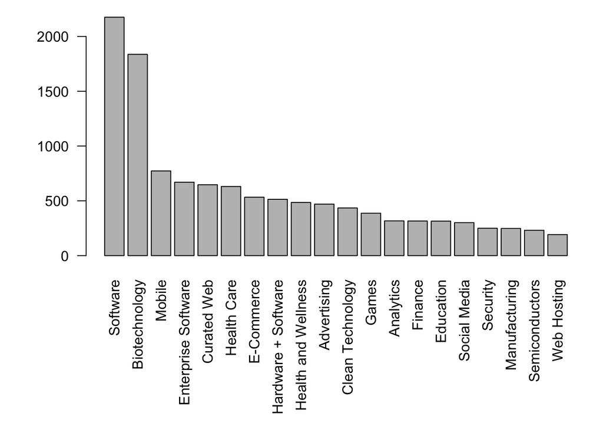

```r
#frequency of companies across markets in descending order
sorted_markets <- sort(table(data$market), decreasing=TRUE)

#taking top n most popular markets of operation
n=20
popular_markets <- sorted_markets[1:n]
par(mar=c(10, 5, 1, 1)) #adjusting margins
barplot(popular_markets, las=2)
```

It looks like there’s clearly a larger portion of companies that are in the Software and Biotechnology markets which we will have to keep in mind.

### Removing Outliers

Let’s now take a look at the Total Funding variable and generate boxplots for each of the most popular markets and their total funding per company. We find many outliers to deal with. To ensure that our tests are accurate we remove some of the prominent outliers.

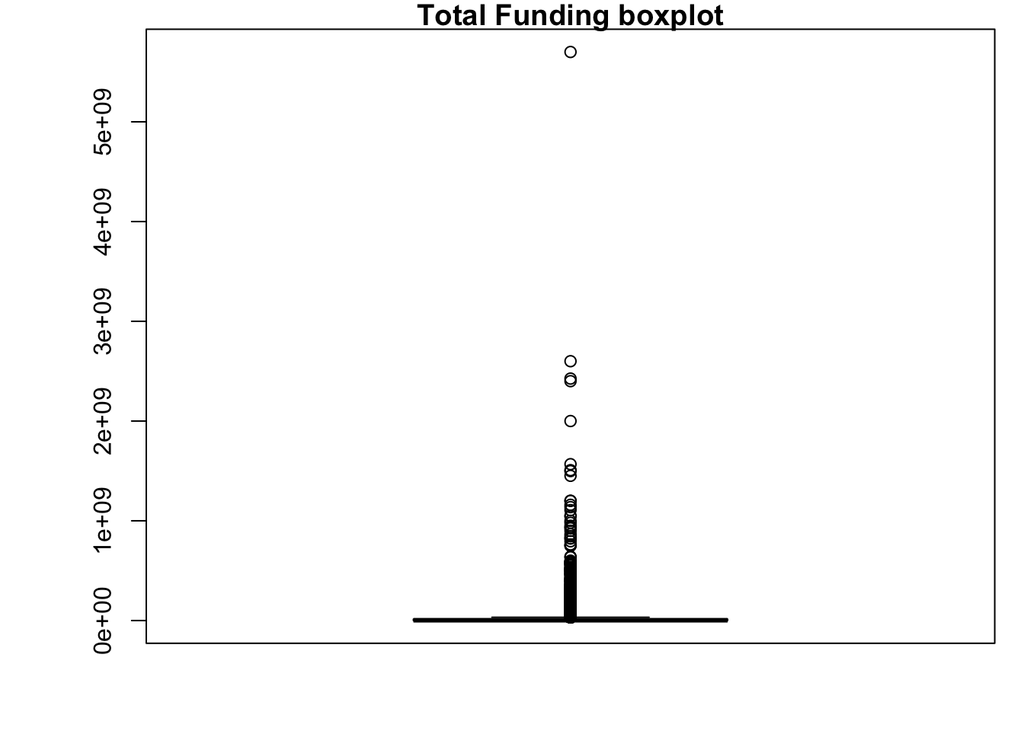

```r
#total funding data
par(mar=c(3, 5, 1, 1))
boxplot(data$funding_total_usd,  main="Total Funding boxplot")
```

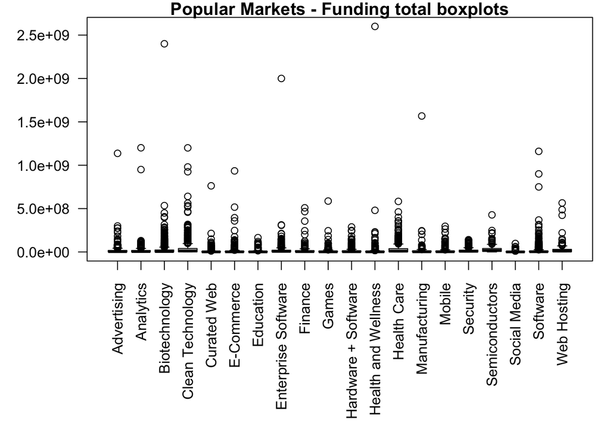

```r
#total funding data for each market
popular_markets = as.data.frame(popular_markets)
popular_markets_data <- filter(data, data$market %in% popular_markets$Var1)
popular_markets_data = na.omit(popular_markets_data)

#drop unused levels
popular_markets_data$market <- droplevels(popular_markets_data$market)

par(mar=c(10, 5, 1, 1))
boxplot(popular_markets_data$funding_total_usd~popular_markets_data$market,las=2, xlab=NULL, ylab=NULL, main="Popular Markets - Funding total boxplots")
```

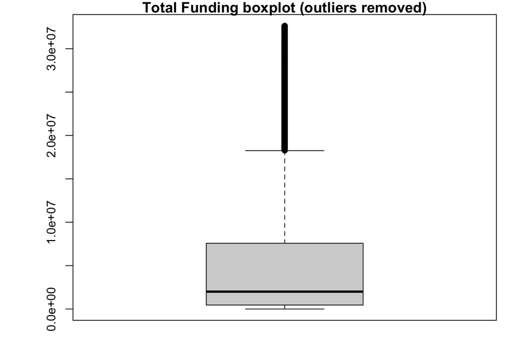

```r
#saving then removing the outliers for total data
outliers <- boxplot(data$funding_total_usd, plot = FALSE)$out

#number of outliers according to boxplot
#length(outliers)
x<-data
x<- x[-which(x$funding_total_usd %in% outliers),]
par(mar=c(3, 5, 1, 1))
boxplot(x$funding_total_usd, main="Total Funding boxplot (outliers removed)")
```

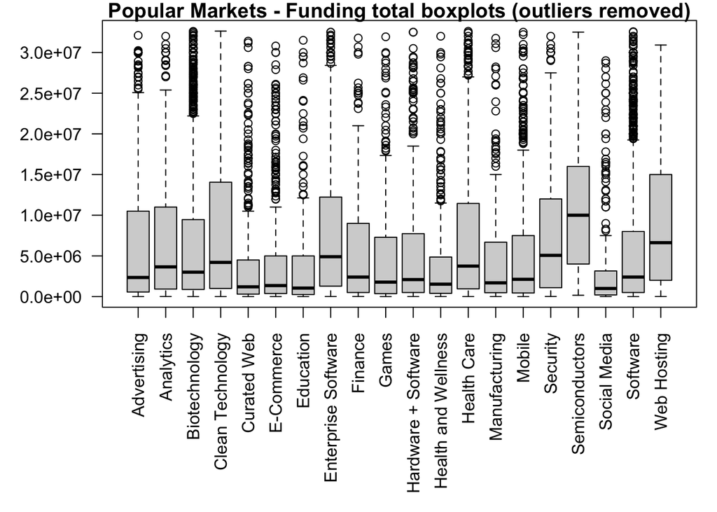

```r
#plot the popular markets boxplots again
popular_markets_data <- filter(x, x$market %in% popular_markets$Var1)
popular_markets_data = na.omit(popular_markets_data)

#drop unused levels
popular_markets_data$market <- droplevels(popular_markets_data$market)

# distribution of data across top 20 popular markets
par(mar=c(10, 5, 1, 1))
boxplot(popular_markets_data$funding_total_usd~popular_markets_data$market, data=popular_markets_data, las=2, xlab=NULL, ylab=NULL ,main="Popular Markets - Funding total boxplots (outliers removed)")
```

It looks like there are quite a large number of outliers outside the range as we cannot see any clear boxplots initially.

After removal of outliers we can now observe the variances across the top 20 markets regarding their total funding values.

```r
summary(popular_markets_data)
```

```
##                    market     funding_total_usd
##   Software            :1996   Min.   :      50
##   Biotechnology       :1488   1st Qu.:  540000
##   Mobile              : 704   Median : 2418066
##   Curated Web         : 616   Mean   : 5913406
##   Enterprise Software : 567   3rd Qu.: 8500000
##   E-Commerce          : 481   Max.   :32630837
##  (Other)              :4298
```

```r
print(paste(c("Market", "Variance (within)", "Mean")))
```

```
## [1] "Market"            "Variance (within)" "Mean"
```

```r
for(i in popular_markets$Var1){
  temp = popular_markets_data[popular_markets_data$market == i,]
  print(paste(c(i, var(temp$funding_total_usd), mean(temp$funding_total_usd))))
}
```

```
## [1] " Software "       "50145457031623.9" "5537396.33767535"
## [1] " Biotechnology "  "64696983841764.5" "6568225.04973118"
## [1] " Mobile "         "50116488864150.4" "5346097.00142045"
## [1] " Enterprise Software " "67787491411105.3"      "7864311.7989418"
## [1] " Curated Web "    "31055876170649.8" "3605695.74837662"
## [1] " Health Care "    "80759366045216.9" "7695980.94260486"
## [1] " E-Commerce "     "43093942645889"   "4356493.98960499"
## [1] " Hardware + Software " "54252427957834"        "5594647.21615721"
## [1] " Health and Wellness " "37144394551427.4"      "4077874.367713"
## [1] " Advertising "    "66563101137842.8" "6529990.43283582"
## [1] " Clean Technology " "85340736650529.3"   "8387299.19620253"
## [1] " Games "          "46263082404239"   "4974197.58146067"
## [1] " Analytics "      "66895030218960.1" "7125777.91208791"
## [1] " Finance "        "55093028413600.4" "5955099.64233577"
## [1] " Education "      "37034447375002.7" "3826839.42281879"
## [1] " Social Media "   "37327751856919"   "3470144.63793103"
## [1] " Security "       "71810292487728.4" "8005679.37735849"
## [1] " Manufacturing "  "54033132675437.6" "5237780.20454545"
## [1] " Semiconductors " "79844931253257.1" "11395940.869281"
## [1] " Web Hosting "    "85281262784800.5" "9694719.49659864"
```

## 2. Check ANOVA assumptions

Check if ANOVA assumptions are valid for average amounts of money raised for each industry (Question 1)

#### a. Equal Variances (Homoscedasticity or homegeity of variance)

```r
#Homogeneity of Variances
bartlett.test(popular_markets_data$funding_total_usd~popular_markets_data$market, data=popular_markets_data)
```

```
##
##  Bartlett test of homogeneity of variances
##
## data:  popular_markets_data$funding_total_usd by popular_markets_data$market
## Bartlett's K-squared = 339.29, df = 19, p-value < 2.2e-16
```

```r
library(HH)
hov(popular_markets_data$funding_total_usd~popular_markets_data$market, data=popular_markets_data)
```

```
##
##  hov: Brown-Forsyth
##
## data:  popular_markets_data$funding_total_usd
## F = 15.33, df:popular_markets_data$market = 19, df:Residuals = 10130,
## p-value < 2.2e-16
## alternative hypothesis: variances are not identical
```

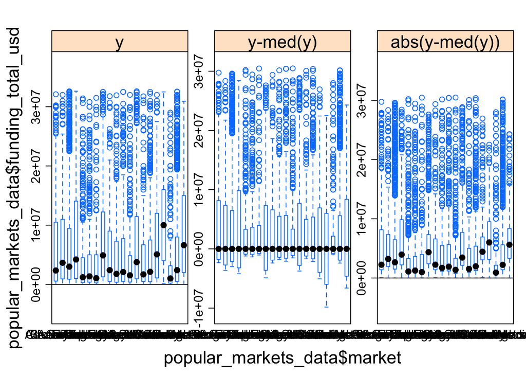

```r
hovPlot(popular_markets_data$funding_total_usd~popular_markets_data$market, data=popular_markets_data)
```

#### b. Normally distributed means

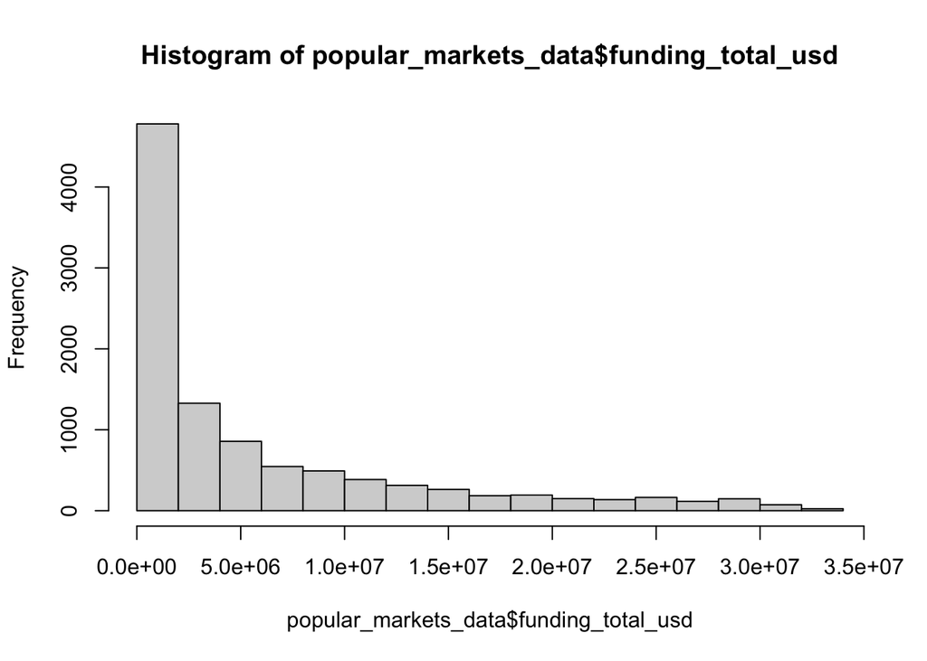

```r
#frequency distribution of total funding amounts
hist(popular_markets_data$funding_total_usd)
```

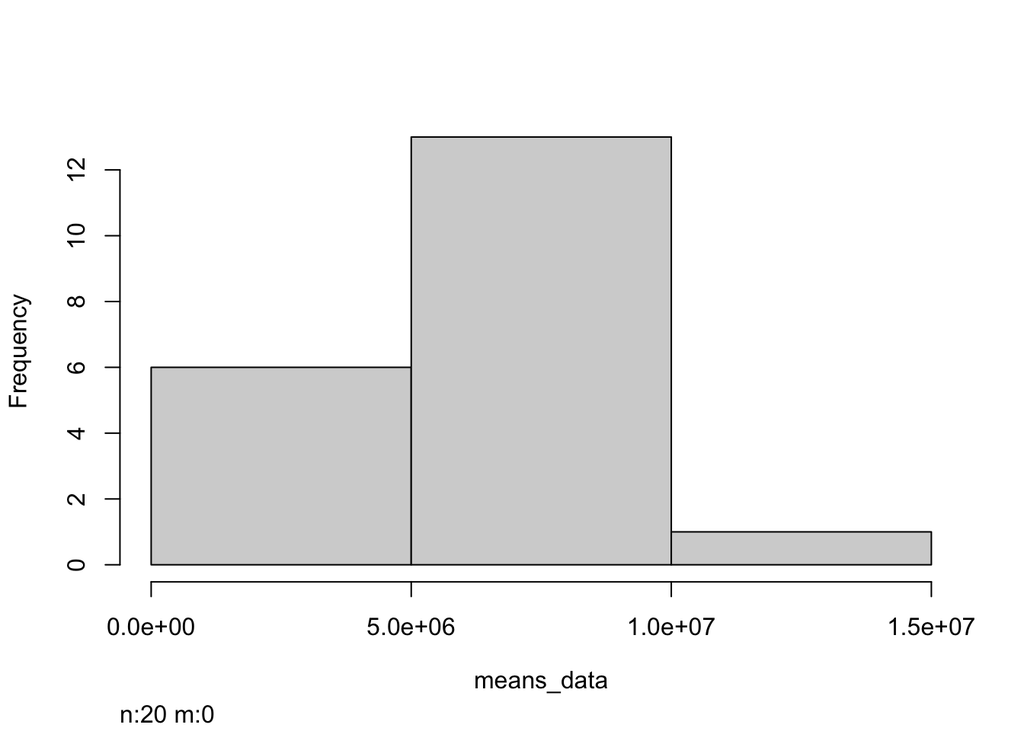

```r
#plotting means of samples (for each category)
means_data = c()
for(i in popular_markets$Var1){
  temp = popular_markets_data[popular_markets_data$market == i,]
  means_data <- c(mean(temp$funding_total_usd), means_data)
}
means_data = as.data.frame(means_data)
hist(means_data, breaks = 6)
```

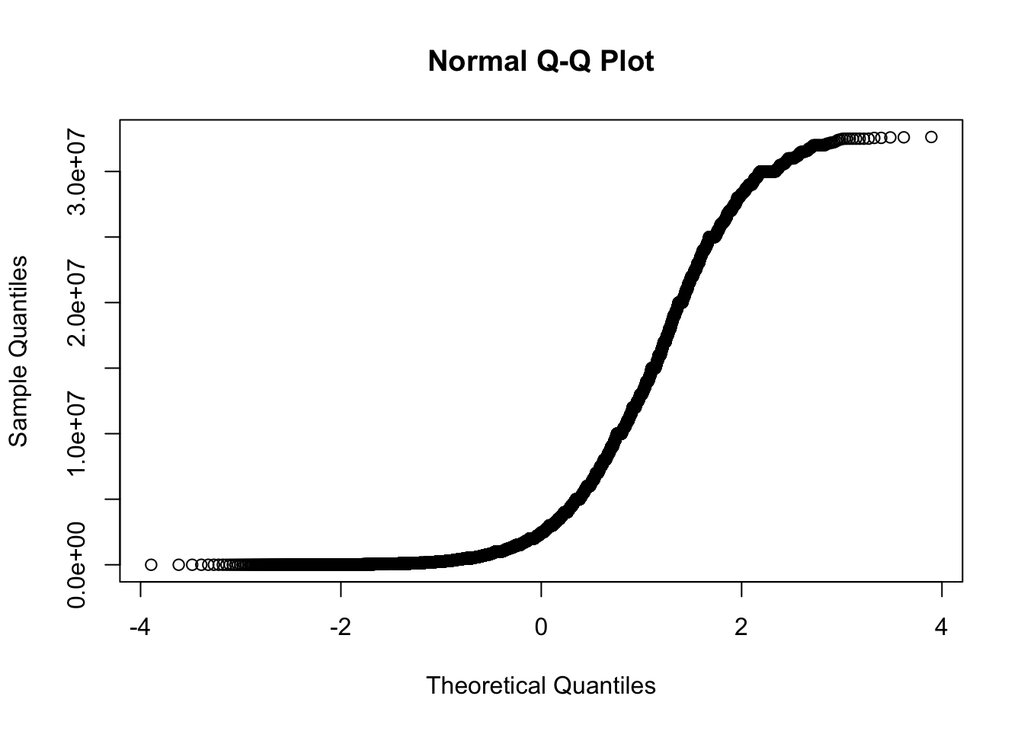

```r
#if data is normal then points should form a straight line
qqnorm(popular_markets_data$funding_total_usd)
```

Need to look into:

Several methods for evaluate normality, including the Kolmogorov-Smirnov (K-S) normality test and the Shapiro-Wilk’s test.

The null hypothesis of these tests is that “sample distribution is normal”. If the test is significant, the distribution is non-normal.

Shapiro-Wilk’s method is widely recommended for normality test and it provides better power than K-S. It is based on the correlation between the data and the corresponding normal scores (Ghasemi and Zahediasl 2012).

Note that, normality test is sensitive to sample size. Small samples most often pass normality tests. Therefore, it’s important to combine visual inspection and significance test in order to take the right decision.

#### c. Independent samples

Assuming independence of samples for this case.

## 3. Perform ANOVA

```r
summary(aov(popular_markets_data$funding_total_usd~popular_markets_data$market))
```

```
##                                Df   Sum Sq   Mean Sq F value Pr(>F)
## popular_markets_data$market    19 2.43e+16 1.279e+15   22.97 <2e-16 ***
## Residuals                   10130 5.64e+17 5.568e+13
## ---
## Signif. codes:  0 '***' 0.001 '**' 0.01 '*' 0.05 '.' 0.1 ' ' 1
```

**ANOVA results in rejecting the null hypothesis that the average total funding in the top 20 market groups is the same**